# Accessing GBIF data

Denisse Fierro Arcos

2022-05-05

# Accessing biological data from GBIF

[GBIF](https://www.gbif.org/) (Global Biodiversity Information Facility) is a global organisation that aims to providing open access data about life (from bacteria to large vertebrate) on Earth to anyone with an internet connection. To facilitate data analysis, GBIF uses Darwin Core data standards.

In this notebook, we will go through the steps necessary to searching and downloading biological data for a particular species of interest. Before going any further, remember that you must have the following:  
* Create a free [GBIF](https://www.gbif.org/) account: Make sure you remember your username, email and password.  
* Download the `rgbif`, `tidyverse` and `usethis` packages.

If you are missing any of the above packages, remember that you can install them using the `install.packages("name_of_package")` function. Do not forget to use the name of the package you want to install in between the quotation marks `""`.

## Introduce yourself to `rgbif`

To be able to download data from GBIF, you must first identify yourself by providing your login details. To avoid writing down this information every time we download data, we can record this in our `.Renviron` file. This file is used to create environmental variables containing sensitive information like usernames and password that can be accessed by `R` only. This way you can share your scripts and keep your login details secured. To edit or create your `.Renviron` file, we will use the `usethis` package.

```r
usethis::edit_r_environ()
```

This will open a new tab titled `.Renviron` which will be blank if it is the first time you are editing it, or if you have edit it before, it will contain previously saved environmental variables. To record your GBIF login details, use the following code (make sure to include your own login details):

```r
GBIF_USER="your_username"
GBIF_PWD="your_password"
GBIF_EMAIL="your_email@email.com"
```

You will need to restart your R session for these changes to take effect. You can do this by going to the `Session -> Restart R` or using the keyboard shortcut `Ctrl+Shift+F10`.

## Querying and loading GBIF data

To do this we will need to load a couple of libraries.

```r
library(rgbif)
library(tidyverse)
```

Now we are ready to start our search. Let’s say we are interested in finding out data for the *Scalloped Hammerhead* (**Sphyrna lewini**) in Australia. The first step is to find the **taxon key** for our species of interest.

```r
#We must use the scientific name in our search. We can also search by other taxonomic levels. For more information use ?name_backbone
slewini_key <- name_backbone(name = "Sphyrna lewini")

#Let's see the results
slewini_key %>%
  glimpse()
```

```
## Rows: 1
## Columns: 22
## $ usageKey       <int> 2418789
## $ scientificName <chr> "Sphyrna lewini (Griffith & Smith, 1834)"
## $ canonicalName  <chr> "Sphyrna lewini"
## $ rank           <chr> "SPECIES"
## $ status         <chr> "ACCEPTED"
## $ confidence     <int> 99
## $ matchType      <chr> "EXACT"
## $ kingdom        <chr> "Animalia"
## $ phylum         <chr> "Chordata"
## $ order          <chr> "Carcharhiniformes"
## $ family         <chr> "Sphyrnidae"
## $ genus          <chr> "Sphyrna"
## $ species        <chr> "Sphyrna lewini"
## $ kingdomKey     <int> 1
## $ phylumKey      <int> 44
## $ classKey       <int> 121
## $ orderKey       <int> 887
## $ familyKey      <int> 2207
## $ genusKey       <int> 2418788
## $ speciesKey     <int> 2418789
## $ synonym        <lgl> FALSE
## $ class          <chr> "Elasmobranchii"
```

With the taxon key we can start our search.

```r
#We will use the function pred to build our query
#We will search for Sphyrna lewini
slewini_query <- occ_download(pred("taxonKey", slewini_key$usageKey),
                            #We will keep records for Australia only
                            pred("country", "AU"),
                            #We will keep presence data only
                            pred("occurrenceStatus", "PRESENT"),
                            #We will keep georeferenced records only
                            pred("hasCoordinate", TRUE),
                            format = )
```

We can check the status of our download query now.

```r
occ_download_wait(slewini_query)
```

```
## status: succeeded
```

```
## download is done, status: succeeded
```

```
## <<gbif download metadata>>
##   Status: SUCCEEDED
##   Format: DWCA
##   Download key: 0265029-210914110416597
##   Created: 2022-05-05T04:37:28.008+00:00
##   Modified: 2022-05-05T04:38:21.880+00:00
##   Download link: https://api.gbif.org/v1/occurrence/download/request/0265029-210914110416597.zip
##   Total records: 1155
##   Request:
##     type:  and
##     predicates:
##       > type: equals, key: TAXON_KEY, value: 2418789
##       > type: equals, key: COUNTRY, value: AU
##       > type: equals, key: OCCURRENCE_STATUS, value: PRESENT
##       > type: equals, key: HAS_COORDINATE, value: true
```

Now we are ready to download the dataset we are interested in.

```r
#This section downloads a zip file to disk
slewini_aus <- occ_download_get(key = slewini_query, path = "Data/",
                                overwrite = T) %>%
  #This section loads zip file into memory
  occ_download_import(slewini_australia_gbif, path = "Data/",
                      na.strings = c("", NA))
```

## Manipulating GBIF data in R

We can check the column names of the dataset we just downloaded.

```r
slewini_aus %>%
  glimpse()
```

```
## Rows: 1,155
## Columns: 257
## $ gbifID                              <int64> 3499611600, 3445416663, 34454117~
## $ abstract                            <lgl> NA, NA, NA, NA, NA, NA, NA, NA, NA~
## $ accessRights                        <lgl> NA, NA, NA, NA, NA, NA, NA, NA, NA~
## $ accrualMethod                       <lgl> NA, NA, NA, NA, NA, NA, NA, NA, NA~
## $ accrualPeriodicity                  <lgl> NA, NA, NA, NA, NA, NA, NA, NA, NA~
## $ accrualPolicy                       <lgl> NA, NA, NA, NA, NA, NA, NA, NA, NA~
## $ alternative                         <lgl> NA, NA, NA, NA, NA, NA, NA, NA, NA~
## $ audience                            <lgl> NA, NA, NA, NA, NA, NA, NA, NA, NA~
## $ available                           <lgl> NA, NA, NA, NA, NA, NA, NA, NA, NA~
## $ bibliographicCitation               <chr> NA, "Project: IMOS / AIMS Acoustic~
## $ conformsTo                          <lgl> NA, NA, NA, NA, NA, NA, NA, NA, NA~
## $ contributor                         <lgl> NA, NA, NA, NA, NA, NA, NA, NA, NA~
## $ coverage                            <lgl> NA, NA, NA, NA, NA, NA, NA, NA, NA~
```

[output cut: 244 more lines]

### Summarising GBIF data

We could keep only the columns we are interested in if we wish. But we can create summary tables with a few lines. We can get the number of observations by sex and life stage for example.

```r
slewini_aus %>%
  count(sex, lifeStage)
```

```
## # A tibble: 10 x 3
##    sex    lifeStage     n
##    <chr>  <chr>     <int>
##  1 FEMALE Immature     40
##  2 FEMALE <NA>          6
##  3 MALE   Immature     60
##  4 MALE   Mature       15
##  5 MALE   <NA>         22
##  6 <NA>   Adult         4
##  7 <NA>   Immature      1
##  8 <NA>   Juvenile      6
##  9 <NA>   Unknown       1
## 10 <NA>   <NA>       1000
```

We can see here that most records do not include information about sex or life stage. We can also check records by state.

```r
slewini_aus %>%
  count(stateProvince)
```

```
## # A tibble: 6 x 2
##   stateProvince          n
##   <chr>              <int>
## 1 New South Wales       42
## 2 Northern Territory    14
## 3 Queensland           155
## 4 Victoria               1
## 5 Western Australia     15
## 6 <NA>                 928
```

Most records do not include information about the state where these animals were observed. Let’s make a plot of records by year.

```r
#Let's check the type of quantity recorded
unique(slewini_aus$organismQuantityType)
```

```
## [1] NA            "individuals" "individual"
```

This means we can simply add the columns individual count and organism quantity.  
You can check the definition of each column included in the downloaded GBIF dataset [here](https://www.gbif.org/data-quality-requirements-occurrences#dcCount).

## Plotting GBIF data

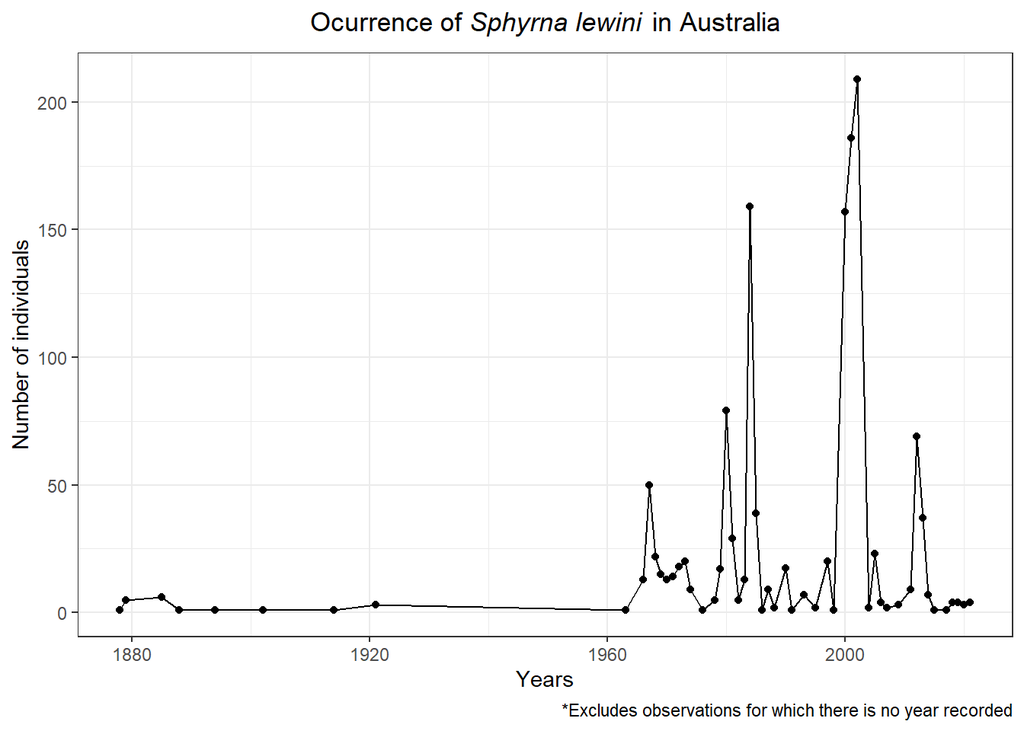

```r
slewini_aus %>%
  #We will change NA values in both columns to 0
  mutate(individualCount = replace_na(individualCount, 0),
         organismQuantity =  replace_na(organismQuantity, 0),
         #Then we will create a new column with the sum of these two columns
         count = rowSums(across(individualCount:organismQuantity))) %>%
  #Now we will change any rows with zero values to one because we selected
  #to include presence data only in our search. This means that each row
  #represents one individual
  mutate(count = case_when(count == 0 ~ 1,
                           T ~ count)) %>%
  #Remove observations without years
  drop_na(year) %>%
  #We make a summary table by year
  group_by(year) %>%
  summarise(n = sum(count)) %>%
  #Now we create a plot
  ggplot(aes(y = n, x = year))+
  geom_point()+
  geom_line()+
  theme_bw()+
  labs(y = "Number of individuals",
       x = "Years",
       title = expression(paste("Ocurrence of ",
                          italic("Sphyrna lewini"),
                          " in Australia")),
       caption = "*Excludes observations for which there is no year recorded")+
  theme(plot.title = element_text(hjust = 0.5))
```